# Constrained and Unconstrained Optimisation Methods in Classification

Kieran Morris

2023-11-07

In this document we will explore the algorithms which solve two optimisation problems is machine learning, that is: the unconstrained optimisation behind logistic regression, and the constrained optimisation behind support vector machines. The first half will feel familiar as the theory can be found in the SC1 notes, however the second will be more independent research.

# 1 Unconstrained Optimisation

Unconstrained optimisation is the easier of the two and is the one covered in the SC1 lecture notes so we will start with that. We will spend about half of this document on unconstrained, before moving onto constrained optimisation - the more fussy sibling of unconstrained optimisation.

## 1.1 Logistic Regression

Logistic regression, despite its name, is not a regression algorithm - it is in fact a classification algorithm. For the context of this document we will restrict ourselves to binary classification, however this can be generalised further.

$$p(y\mid x;w) = \sigma(f(x;w)\cdot y)$$
and then the negative log-likelihood over our observed data:
$$\mathbf{Obj(w)} = -\sum_{i=1}^n \ln \sigma(f(x_i;w)\cdot y_i).$$
For which maximising this essentially finds a maximum likelihood estimate for classification - and as a bonus we get a boundary line where $f(x;w) = 0$. Note that different sources may have different constructions of $\mathbf{Obj}$ including if $y \in \{0,1\}$ instead of $y \in \{1,-1\}$, howver our version is $\mathbf{Obj}$ectively the prettiest.

Unlike direct regression problems, there is no exact solution for this optimisation problem, so we must resort to numerical estimation. Fortunately our objective function is a differentiable multivariate function, which we know how to minimise.

The following is an implimentation of Logistic Regression using the built in `glm` function.

### 1.1.1 Example: Quadratic Feature Transform

Consider this simple example which employs a feature transform. Consider the following dataset:

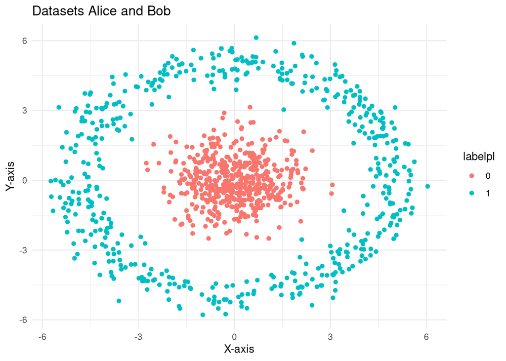

```r
source("/home/et18646/Documents/PhD/First_Year/TB1/SC1/Assessed_Coursework/OptimClassy/R/Logistic_Regression.r")
set.seed(69)
normal_data <- as.data.frame(mvrnorm(n = 500, mu = c(0, 0), Sigma = matrix(c(1, 0, 0, 1), nrow = 2)))
names(normal_data) <- c("x","y")

ring_data <- generate_ring_points(center = c(0, 0), n_points = 500, radius = 5, width = 0.5)

# Combine the datasets
combined_data <- rbind(normal_data, ring_data)
combined_data$labelpl <- rep(c('0', '1'), each = 500)
combined_data$label <- rep(c(0,1), each = 500)

# Plot the datasets using ggplot2
pl <- ggplot(combined_data, aes(x = x, y = y, color = labelpl)) +
geom_point() +
labs(title = "Datasets Alice and Bob",x = "X-axis",y = "Y-axis") +
theme_minimal()

print(pl)
```

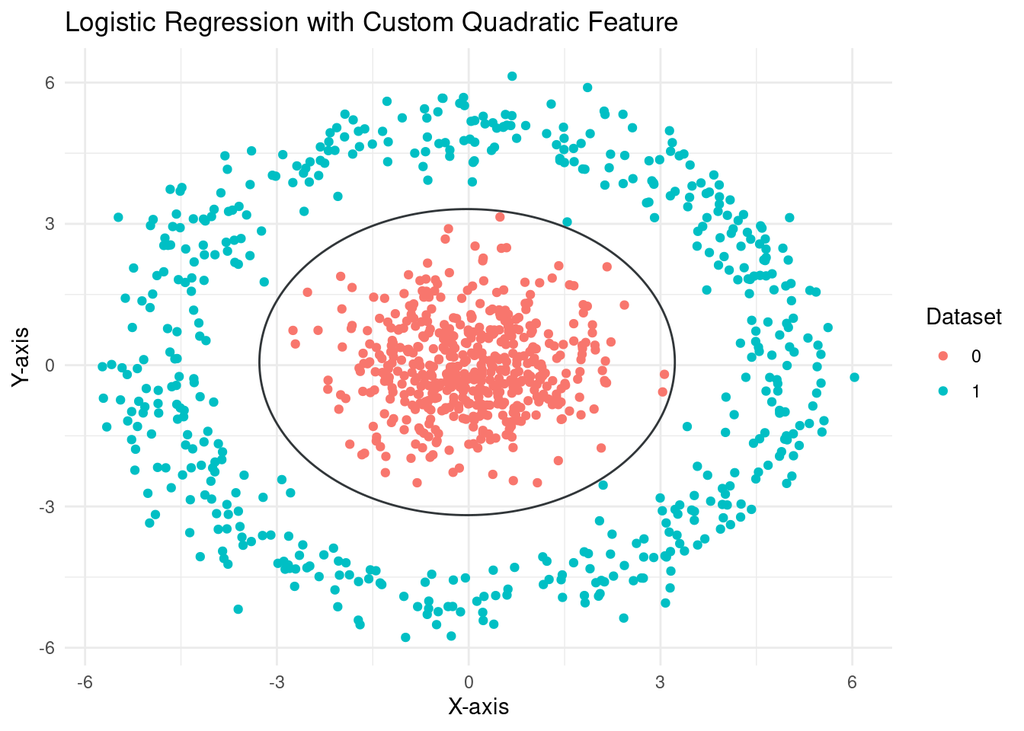

```r
combined_data_transformed <- combined_data
combined_data_transformed$xy <- (combined_data$x)^2 + (combined_data$y)^2
#Performing the feature transform

logistic_model <- glm(label ~ x + y + xy, data = combined_data_transformed, family = "binomial")
#Using glm to perform the logistic regression model

coefficients <- coef(logistic_model)
logistic_function <- function(x,y){
  return(coefficients[1]+coefficients[2]*x+coefficients[3]*y+coefficients[4]*(x^2+y^2))
}

x_values <- seq(-4,4,length.out=100)
y_values <- seq(-4,4,length.out= 100)
grid <- expand.grid(x = x_values,y= y_values)
grid$z <- logistic_function(grid$x,grid$y)

pl2 <- ggplot(combined_data_transformed, aes(x = x, y = y, color = labelpl)) +
  geom_point() +
  geom_contour(data = grid, aes(x = x, y = y, z = z), breaks = 0.5, color = "#313639", linetype = "solid") +
  labs(title = "Logistic Regression with Custom Quadratic Feature",
       x = "X-axis",
       y = "Y-axis",
       color = "Dataset") +
  theme_minimal()

print(pl2)
```

The function itself returns quite a lot of information, including predictions and residuals. Unfortunately it doesn’t return the objective function it minimises (although we have that analytically) or the minima that the objective function achieves (although we can derive it via plugging in $w$ to our objective function).

Something to note is that `glm` returns the message

```r
#Warning messages:
#1: glm.fit: algorithm did not converge
```

Implying that whatever optimisation algorithm glm uses didn’t find the local minima to its satisfaction. Maybe we can do better.

### 1.1.2 Example: Trigonometric Feature Transform

## 1.2 Gradient Descent

Gradient descent is a pretty slow but fundamental optimisation algorithm, as it forms the basis for complex optimisation like Newton methods and stochastic gradient descent. It builds on the principle that the for some multivariable functional $f:\mathbb{R}^d \rightarrow \mathbb{R}$ the gradident $\nabla f$ points in the direct of steepest ascent. So recursively taking steps in the *other* direction should converge to a minima.

We formally construct our algorithm as follows:

Suppose we have a continuously differentiable $f:\mathbb{R}^d \rightarrow \mathbb{R}$, fix a learning rate $\epsilon >0$ and and inital point $x_0$, then we define the following sequence:
$$x_{n+1} = x_n - \epsilon \nabla f$$
Continue this iteration until $|x_n - x_{n-1}| < \epsilon_0$ for some sufficiently small $\epsilon_0$. One thing to note is that we need to have $\nabla f$, for our context we will utilize the `numDeriv` package. Which employs *automatic differentiation* to analytically compute the derivative of a functional.

Lets impliment this in `R` code using the Rosenbrock function as a toy example, which has a global minima at $(1,1)$.

```r
library(numDeriv)
library(ggplot2)
source("/home/et18646/Documents/PhD/First_Year/TB1/SC1/Assessed_Coursework/OptimClassy/R/Optimise_Function.r")

objective_function <- function(x){return((1-x[1])^2 + 100*(x[2]-(x[1])^2)^2)}

grad_objective_function <- function(x){
  gradient <- grad(objective_function,x)
  return(gradient)}

x_0 <- c(-1,1)
learnrt <- 0.003
max_iterations <- 1000

gradient_descent(objective_function,grad_objective_function,x_0,learnrt,max_iterations)
```

```
## [1] 0.7818451 0.6099427
```

We see that even after 1000 iterations, our primitive gradient descent algorithm is nowhere near the true minima, of course this is only one choice of $\epsilon$, so lets vary it over a range and see how close we get to the true minima:

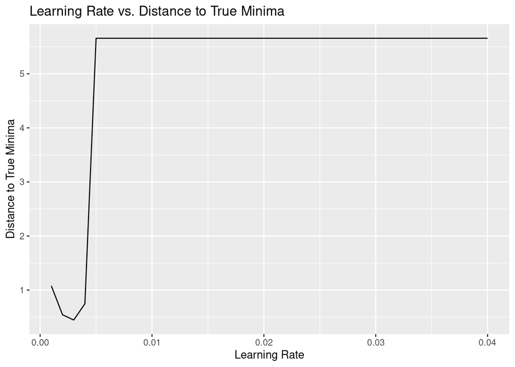

```r
true_minima <- c(1, 1)

# Range of learning rates to span over
learning_rates <- seq(0.001, 0.04, by = 0.001)

# Container for results
results <- data.frame(learning_rate = numeric(), distance_to_true_minima = numeric())

# Perform gradient descent for each learning rate
for (lr in learning_rates) {
  x_final <- gradient_descent(objective_function, grad_objective_function, x_0, lr, max_iterations)
  distance_to_true_minima <- sqrt(sum((x_final - true_minima)^2))

  results <- rbind(results, data.frame(learning_rate = lr, distance_to_true_minima = distance_to_true_minima))
}

# Plot the results
ggplot(results, aes(x = learning_rate, y = distance_to_true_minima)) +
  geom_line() +
  labs(title = "Learning Rate vs. Distance to True Minima", x = "Learning Rate", y = "Distance to True Minima")
```

# 2 Constrained Optimisation

## 2.1 Support Vector Machines

Support Vector Machines are a family of (typically binary) classification models often used in machine learning contexts. They allow for kernel methods, which is the implimentation of a (possibly infinite dimensional) feature transform to allow for much more exotic classification. In fact in my group project - Classifying Higgs Boson data - we implimented SVM with an RBF kernel, which is a very common infinite dimensional feature transform.

### 2.1.1 Construction and Application

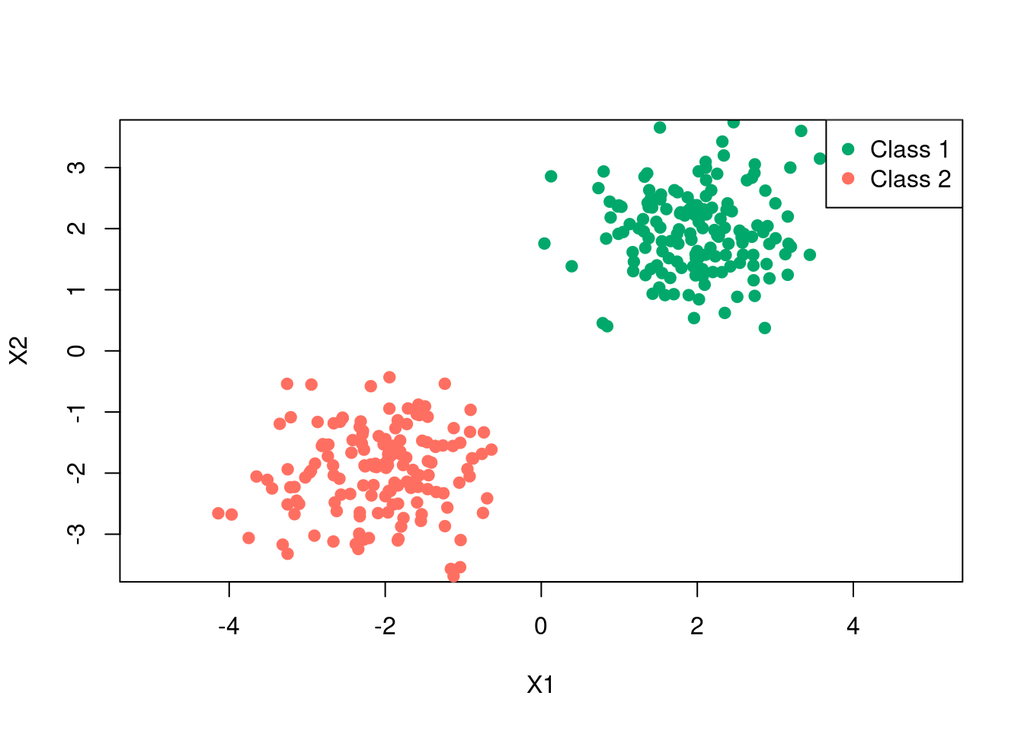

```r
source("/home/et18646/Documents/PhD/First_Year/TB1/SC1/Assessed_Coursework/OptimClassy/R/SVM_Function.R")
# Parameters for the distributions, these will be used later on too
set.seed(11)
mean1 <- c(2, 2)
mean2 <- c(-2, -2)
cov_matrix <- matrix(c(0.5, 0, 0, 0.5), nrow = 2)
n_samples <- 150

#generate the data
data <- Binary_MVN(mean1, mean2, cov_matrix, n_samples)

#plot the data
plot_Data(data)
```

There are multiple lines which can seperate the data, and different classifiers may return different outputs, here are a few examples of linear classifiers attempting this:

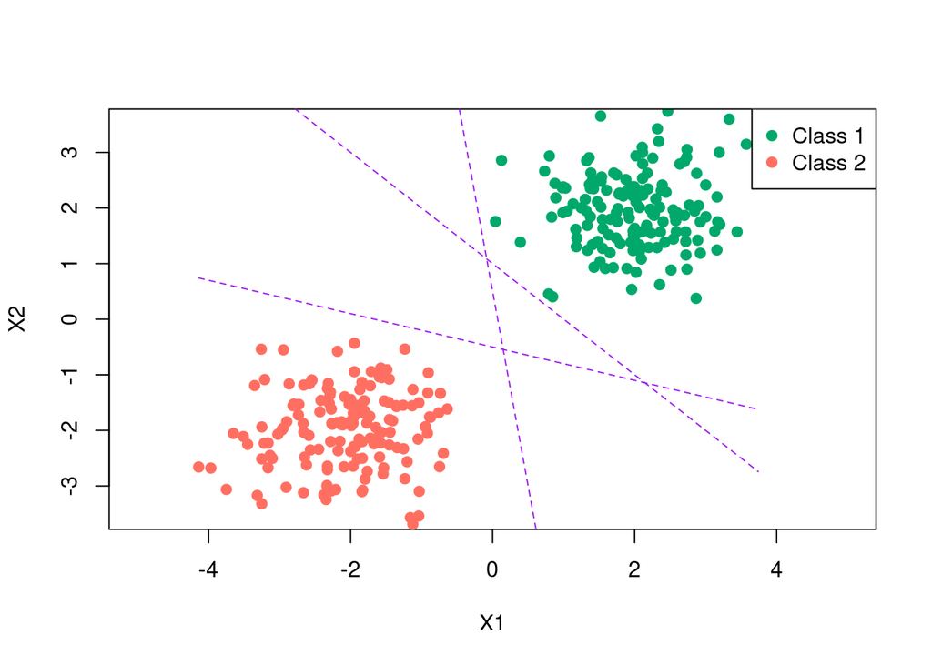

```r
coefficients_list <- list(c(1, 1, -1), c(-7, -1, 0.5), c(-3, -10, -5))
plot_DecisionBoundary(coefficients_list, data)
```

SVM runs on the principle that for any classifying line we have, we can draw a *Margin* around it, which is perpendicular at each point to the classifier line. We specify each point as the classifier does not need to be linear. The idea is to maximise the width of this margin while minimising the amount of data points trapped inside it.

but it may be easy to see that if we have a case where our datasets are *Linearly Seperable*, the best classifier is the following:

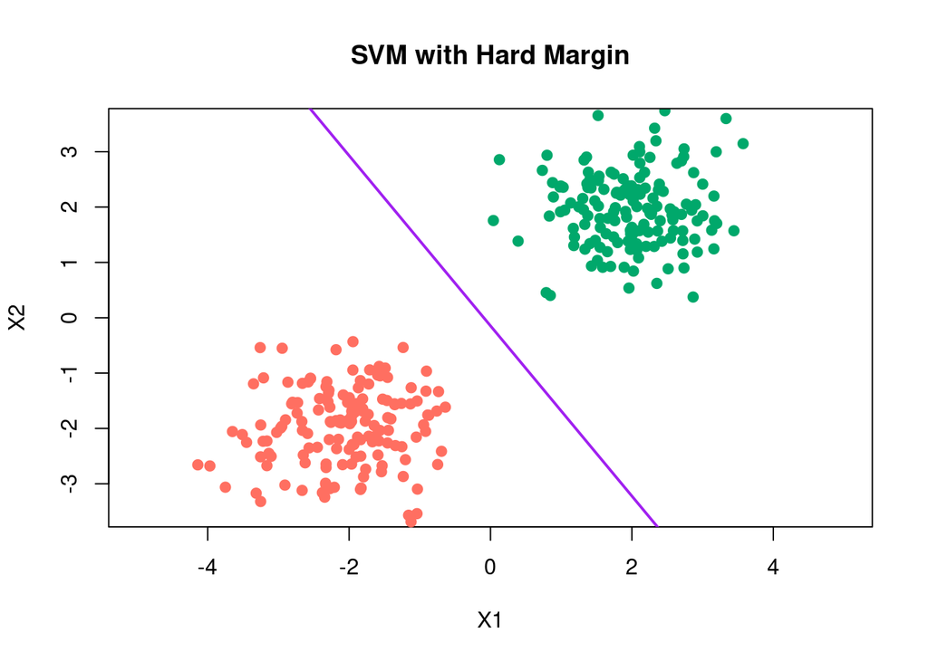

[output not shown]

```r
Run_SVM(data)
```

## 2.2 Hard Margin

## 2.3 The Optimisation Problem

# 3 Optimisation Methods

## 3.1 Gradient Descent

## 3.2 Newtons Method